# Exercises and Solutions - Statistics for Biology FS 2020

Stephan Peischl

## Week 1 (26.02.2020)

#### Exercise 1

The peppered moth (Biston betularia) occurs in two types: peppered (speckled black and white) and melanic (black). A researcher wished to measure the proportion of melanic individuals in the peppered moth population in England, to examine how this proportion changed from year to year in the past. To accomplish this, she photographed all the peppered moth specimens available in museums and large private collections and grouped them by the year in which they had been collected. Based on this sample, she calculated the proportion of melanic individuals in every year. The people who collected the specimens, she knew, would prefer to collect whichever type was rarest in any given year, since those would be the most valuable.

1. Can the specimens from any given year be considered a random sample from the moth population?
2. If not a random sample, what type of sample is it?
3. What type of error might be introduced by the sampling method when estimating the proportion of melanic moths?

##### Solutions

1. No. Collectors did not choose randomly, but prefered rarer types over more common ones.
2. It is a sample of convenience.
3. Thus, there is bias in every year’s sample because rare types are over represerented. Further this bias might change across years as the frequencies of the two morphs have changed over time.

#### Exercise 2

Which of the following numerical variables are continuous? Which are discrete? (Note: Discrete variables are those that have a finite set of predefined values, whereas continuous variables can take any value within a given interval.)

1. Number of injuries sustained in a fall
2. Fraction of birds in a large sample infected with avian flu virus
3. Number of crimes committed by a randomly sampled individual
4. Logarithm of body mass

##### Solutions

1. Discrete.
2. Technically it is a discrete variable (because fractions can be enumerated / are retricted to fintely many values in a fintie sample) but it makes sense to treat it as a continous variable if the sample is very large.
3. Discrete. There are no half crimes.
4. Continous. Body mass is continous and hence the log as well.

#### Exercise 3

For each of the following studies, say which is the explanatory variable and which is the response variable. Also, say whether the study is observational or experimental.

1. Forestry researchers wanted to compare the growth rates of trees growing at high altitude to that of trees growing at low altitude. They measured growth rates using the space between tree rings in a set of trees harvested from a natural forest.
2. Researchers randomly assign diabetes patients to two groups. In the first group, the patients receive a new drug, tasploglutide, whereas patients in the other group receive standard treatment without the new drug. The researchers compared the rate of insulin release in the two groups.
3. Psychologists tested whether the frequency of illegal drug use differs between people suffering from schizophrenia and those not having the disease. They measured drug use in a group of schizophrenia patients and compared it with that in a similar sized group of randomly chosen people.
4. Spinner Hansen et al. (2008) studied a species of spider whose females often eat males that are trying to mate with them. The researchers removed a leg from each male spider in one group (to make them weaker and more vulnerable to being eaten) and left the males in another group undamaged. They studied whether survival of males in the two groups differed during courtship.
5. Bowen et al. (2012) studied the effects of advanced communication therapy for patients whose communication skills had been affected by previous strokes. They randomly assigned two therapies to stroke patients. One group received advanced communication therapy and the other received only social visits without formal therapy. Both groups otherwise received normal, best-practice care. After six months, the communication ability (as measured by a standardized quantitative test score) was measured on all patients.

##### Solutions

1. E(xplanatory): Altitude (categorical: high vs low) R(esponse): Growth rate S(tudy type): Observational
2. E: Treatment (standard vs. tasploglutide) R: Rate of insulin release S: Experimental
3. E: Health status (schizophrenia vs. healthy) R: Frequency of illegal drug use S: Observational
4. E:Number of legs R: Survival propability S: Experimental
5. E: Treatment (advanced communication therapy vs. social visits without formal therapy) R: Communication ability S: Experimental

#### Exercise 4

During World War II, the British Royal Air Force estimated the density of bullet holes on different sections of planes returning to base from aerial sorties. Their goal was to use this information to determine which plane sections most needed additional protective shields. (It was not possible to reinforce the whole plane, because it would weigh too much.) They found that the density of holes was highest on the wings and lowest on the engines and near the cockpit, where the pilot sits (their initial conclusion, that therefore the wings should be reinforced, was later shown to be mistaken). What is the main problem with the sample: bias or large sampling error? What part of the plane should have been reinforced?

[figure not shown]

Figure for exercise 4: Airplane bullet holes

##### Solution

The main problem is a strong bias in the sample. To see this, consider the sample of planes that were used in this study. Only planes that were *not* hit in critical areas were available to estimate the distribution of bullet holes. Planes that were hit in a critical area, i.e., one that leads to a crash, were not available because they did not return to base. With this knowledge, it becomes clear that it would have been better to reinforce the areas were no, or very little, bullet holes were found, namely the cockpit and engine.

#### Exercise 5

An important quantity in conservation biology is the number of plant and animal species inhabiting a given area. To survey the community of small mammals inhabiting Kruger National Park in South Africa, a large series of live traps were placed randomly throughout the park for one week in the main dry season of 2004. Traps were set each evening and checked the following morning. Individuals caught were identified, tagged (so that new captures could be distinguished from recaptures), and released. At the end of the survey, the total number of small mammal species in the park was estimated by the total number of species captured in the survey.

1. What is the parameter being estimated in the survey?
2. Is the sample of individuals captured in the traps likely to be a random sample? Why or why not? In your answer, address the two criteria that define a sample as random.
3. Is the number of species in the sample likely to be an unbiased estimate of the total number of small mammal species in the park?

## Week 2 (04.03.2020)

#### Exercise 6

We use the MPG data set introduced in the lecture. Answer the following questions. You can use base R or ggplot if not otherwise specified.

1. Run ggplot(data = mpg). What do you see?
2. How many rows are in mpg? How many columns?
3. What does the drv variable describe? Read the help for ?mpg to find out.
4. Make a scatterplot of hwy vs cyl.
5. What happens if you make a scatterplot of class vs drv? Why is the plot not useful?
6. What is wrong with this code? Why are the points not blue?

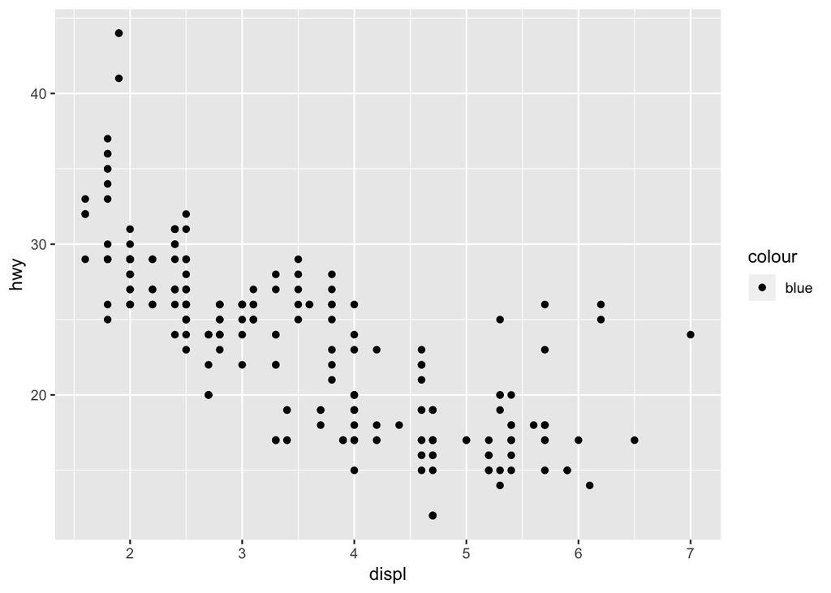

```r
ggplot(data = mpg) +

  geom_point(mapping = aes(x = displ, y = hwy, color = "blue"))
```

7. Map a continuous variable to color, size, and shape. How do these aesthetics behave differently for categorical vs. continuous variables?
8. Fix the following code:

```
ggplot(data = mpg)

+ geom_point(mapping = aes(x = displ, y = hwy))
```